# Finding loop differences between HiChIP H3K27ac for EBNA3C On/Off

All hichipper data here: jun/hichip_k27ac_ebna3c/tmp The mango files are as such: EBNA3Coff.filt.intra.loop_counts.bedpe # 16128550 GEN00140393.filt.intra.loop_counts.bedpe # 7510876 GEN00140394.filt.intra.loop_counts.bedpe # 8618495 EBNA3Con.filt.intra.loop_counts.bedpe # 8911604 GEN00140395.filt.intra.loop_counts.bedpe # 4142674 GEN00140396.filt.intra.loop_counts.bedpe # 4775241

```r
library(diffloop)
library(ggplot2)
library(GenomicRanges)
library(ggrepel)
library(DESeq2)
library(Repitools)
```

This is what “full”" looks like:

```r
dim(full)
```

| anchors | interactions | samples | colData | rowData |
| --- | --- | --- | --- | --- |
| 18279 | 40931 | 6 | 2 | 1 |

```r
head(full, 4)
```

```
An object of class "loops"
Slot "anchors":
GRanges object with 4 ranges and 0 metadata columns:
      seqnames        ranges strand
         <Rle>     <IRanges>  <Rle>
  [1]     chr1 713191-716177      *
  [2]     chr1 756283-757504      *
  [3]     chr1 825037-827414      *
  [4]     chr1 838721-840284      *
  -------
  seqinfo: 25 sequences from an unspecified genome; no seqlengths

Slot "interactions":
     left right
[1,]    1     3
[2,]    1    25
[3,]    2     4
[4,]    3     4

Slot "counts":
     EBNA3Coff.filt.intra EBNA3Con.filt.intra GEN00140393.filt.intra
[1,]                    1                   1                      1
[2,]                    0                   1                      0
[3,]                    1                   0                      1
[4,]                    2                   0                      2
     GEN00140394.filt.intra GEN00140395.filt.intra GEN00140396.filt.intra
[1,]                      0                      0                      1
[2,]                      0                      0                      1
[3,]                      0                      0                      0
[4,]                      0                      0                      0

Slot "colData":
                       sizeFactor    groups
EBNA3Coff.filt.intra    1.9611218 EBNA3Coff
EBNA3Con.filt.intra     1.4708414  EBNA3Con
GEN00140393.filt.intra  0.6609011 EBNA3Coff
GEN00140394.filt.intra  1.1224620 EBNA3Coff

Slot "rowData":
  loopWidth
1    111541
2   1764078
3     82609
4     13277
```

Remove and loops that merged together from import and self loops

```r
full = subsetLoops(full, full@rowData$loopWidth >= 5000)
full = removeSelfLoops(full)
full_corrected = mangoCorrection(full, FDR = 0.05)
dim(full_corrected)
```

| anchors | interactions | samples | colData | rowData |
| --- | --- | --- | --- | --- |
| 15595 | 23781 | 6 | 2 | 3 |

```r
cm <- full_corrected@counts
EBNA3COff <- ((cm[,3]>=2 &cm[,4]==0)|(cm[,4]>=2&cm[,3]==0))
EBNA3COn <- ((cm[,5]>=2 &cm[,6]==0)|(cm[,6]>=2&cm[,5]==0))
qc_filt <- subsetLoops(full_corrected, !(EBNA3COff | EBNA3COn))
dim(qc_filt)
```

| anchors | interactions | samples | colData | rowData |
| --- | --- | --- | --- | --- |
| 15327 | 21514 | 6 | 2 | 3 |

Filtering complete, lets look at sample quality

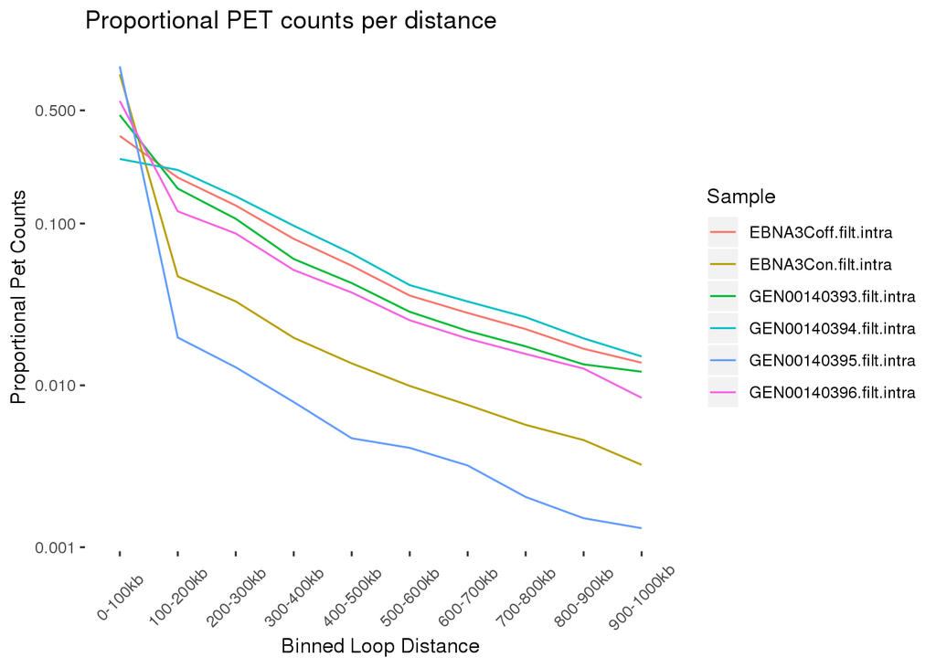

```r
p1 = loopDistancePlot(qc_filt)
p1
```

Looks great!

```r
loopMetrics(qc_filt)
```

```
       EBNA3Coff.filt.intra EBNA3Con.filt.intra GEN00140393.filt.intra
unique                24475               59448                  11200
       GEN00140394.filt.intra GEN00140395.filt.intra
unique                  13376                  45003
       GEN00140396.filt.intra
unique                  15990
```

# Size Factor Adjustment

Take a look at the Size Factor:

```r
pcp1dat <- qc_filt
pcp1dat@colData$sizeFactor <- c(16128550,8911604,7510876,8618495,4142674,4775241)/8911604
pcp1 <- pcaPlot(pcp1dat) + geom_text_repel(aes(label=gsub('.filt.intra','',rownames(pcp1dat@colData)))) +
  scale_x_continuous(limits = c(-100,100)) + ggtitle("PC Plot with no Size Factor Correction") +
  scale_y_continuous(limits = c(-100, 100))
  theme(legend.position="none")
```

```
List of 1
 $ legend.position: chr "none"
 - attr(*, "class")= chr [1:2] "theme" "gg"
 - attr(*, "complete")= logi FALSE
 - attr(*, "validate")= logi TRUE
```

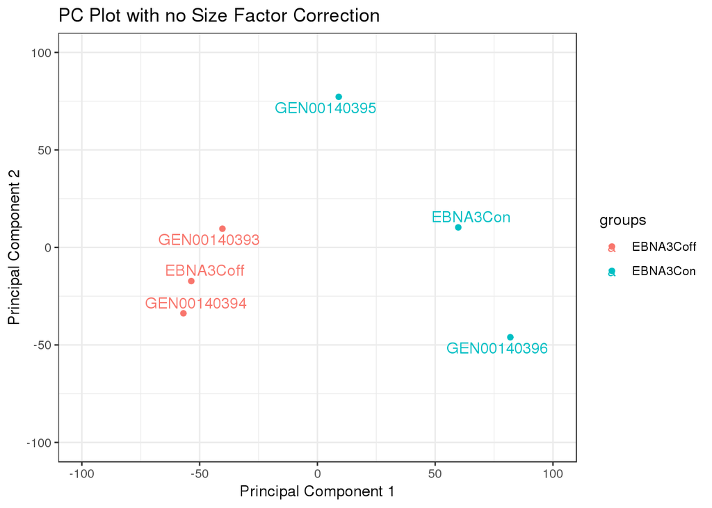

```r
pcp1
```

This is before Size Factor adjustment. Lets adjust based on counts and try this again:

```r
pcp2 <-pcaPlot(qc_filt) + geom_text_repel(aes(label=gsub('.filt.intra','',rownames(pcp1dat@colData)))) +
    scale_x_continuous(limits = c(-100, 100)) + ggtitle("PC Plot with Size Factor Correction") +
    scale_y_continuous(limits = c(-100, 100))
    theme(legend.position="none")
```

```
List of 1
 $ legend.position: chr "none"
 - attr(*, "class")= chr [1:2] "theme" "gg"
 - attr(*, "complete")= logi FALSE
 - attr(*, "validate")= logi TRUE
```

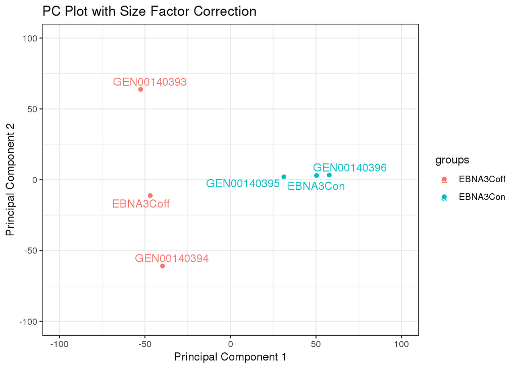

```r
pcp2
```

Size Correction works better!

# Differential Loop Calling

EBNA3C on vs off, lets look first at the biological replicates (3,4 and 5,6)

```r
km_filt = qc_filt[,c(3,4,5,6)]
dim(km_filt)
```

| anchors | interactions | samples | colData | rowData |
| --- | --- | --- | --- | --- |
| 15252 | 21379 | 4 | 2 | 3 |

1. Using edgeR to correct differential features

```r
km_res = quickAssoc(km_filt)
head(km_res@rowData)
```

|  | loopWidth | mango.FDR | mango.P | logFC | logCPM | LR | PValue | FDR |
| --- | --- | --- | --- | --- | --- | --- | --- | --- |
| 1 | 111541 | 8.526129e-04 | 3.678338e-04 | 0.1139714 | 7.097388 | 0.004673827 | 0.9454948 | 0.9461586 |
| 2 | 1764078 | 2.405775e-05 | 2.507460e-06 | 2.3758236 | 6.947201 | 1.448085700 | 0.2288354 | 0.2968822 |
| 3 | 266999 | 2.313607e-04 | 7.901763e-05 | -2.2618522 | 6.947201 | 1.248246805 | 0.2638876 | 0.2968822 |
| 4 | 360682 | 3.972886e-04 | 1.528392e-04 | 2.3988843 | 6.956342 | 1.464573914 | 0.2262038 | 0.2968822 |
| 5 | 318672 | 1.138611e-04 | 3.085204e-05 | -2.2618522 | 6.947201 | 1.248246805 | 0.2638876 | 0.2968822 |
| 6 | 141446 | 1.425385e-05 | 1.388269e-06 | 0.1139714 | 7.097388 | 0.004673827 | 0.9454948 | 0.9461586 |

2. Using a mean-variance for Bayes Analysis

```r
km_res2=quickAssocVoom(km_res)
```

```
Removing intercept from test coefficients
```

```r
head(km_res2@rowData)
```

|  | loopWidth | mango.FDR | mango.P | logFC | logCPM | LR | PValue | FDR | logFC | AveExpr | t | P.Value | adj.P.Val | B |
| --- | --- | --- | --- | --- | --- | --- | --- | --- | --- | --- | --- | --- | --- | --- |
| 1 | 111541 | 8.526129e-04 | 3.678338e-04 | 0.1139714 | 7.097388 | 0.004673827 | 0.9454948 | 0.9461586 | 0.1655070 | 5.578673 | 0.1620562 | 0.8712624 | 0.8798323 | -4.599766 |
| 2 | 1764078 | 2.405775e-05 | 2.507460e-06 | 2.3758236 | 6.947201 | 1.448085700 | 0.2288354 | 0.2968822 | 0.9579883 | 5.182433 | 0.6507987 | 0.5151799 | 0.7059849 | -4.596449 |
| 3 | 266999 | 2.313607e-04 | 7.901763e-05 | -2.2618522 | 6.947201 | 1.248246805 | 0.2638876 | 0.2968822 | -0.6279730 | 5.182433 | -0.4630812 | 0.6433085 | 0.7059849 | -4.597252 |
| 4 | 360682 | 3.972886e-04 | 1.528392e-04 | 2.3988843 | 6.956342 | 1.464573914 | 0.2262038 | 0.2968822 | 0.9554675 | 5.182433 | 0.6490862 | 0.5162861 | 0.7059849 | -4.596454 |
| 5 | 318672 | 1.138611e-04 | 3.085204e-05 | -2.2618522 | 6.947201 | 1.248246805 | 0.2638876 | 0.2968822 | -0.6279730 | 5.182433 | -0.4630812 | 0.6433085 | 0.7059849 | -4.597252 |
| 6 | 141446 | 1.425385e-05 | 1.388269e-06 | 0.1139714 | 7.097388 | 0.004673827 | 0.9454948 | 0.9461586 | 0.1655070 | 5.578673 | 0.1620562 | 0.8712624 | 0.8798323 | -4.599766 |

Lets see how the results are when comparing the two models.

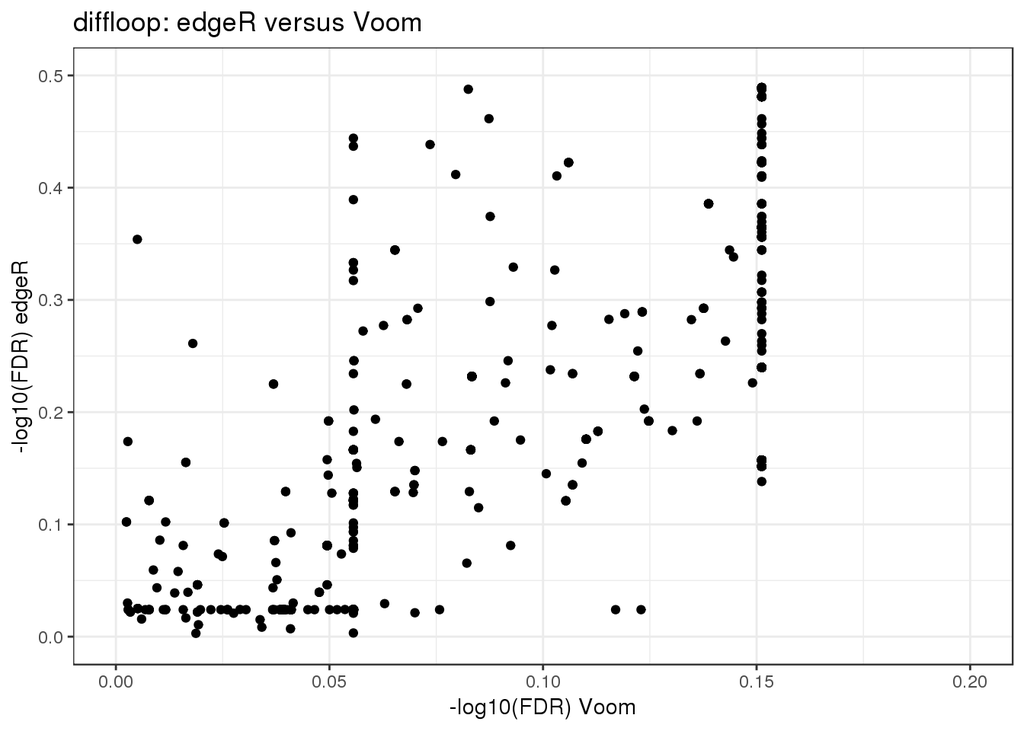

```r
fdrmat <- -log10(km_res2@rowData[,c(8,13)])
fdrmatdf <- setNames(data.frame(fdrmat), c("edgeR", "Voom"))
qplot(fdrmatdf$Voom, fdrmatdf$edgeR)+labs(title = "diffloop: edgeR versus Voom",
    x = "-log10(FDR) Voom", y = "-log10(FDR) edgeR") + scale_y_continuous(limits = c(0, 0.5)) +
    scale_x_continuous(limits = c(0, 0.2)) + theme_bw()
```

Looking at the correlations:

```r
cor(fdrmatdf$Voom, fdrmatdf$edgeR)
```

```
[1] 0.9322141
```

```r
cor(fdrmatdf$Voom, fdrmatdf$edgeR, method = "spearman")
```

```
[1] 0.9002558
```

Filter loops on min size and number of counts per loop in samples In this case, we take loops > 2kb and having at least 1 read in 2 of the samples

```r
qcLoops = filterLoops(km_filt, width = 2000, nreplicates = 1, nsamples = 2)
dim(km_filt)
```

| anchors | interactions | samples | colData | rowData |
| --- | --- | --- | --- | --- |
| 15252 | 21379 | 4 | 2 | 3 |

```r
dim(qcLoops)
```

| anchors | interactions | samples | colData | rowData |
| --- | --- | --- | --- | --- |
| 5052 | 3655 | 4 | 2 | 3 |

edgeR negative binomial test again

```r
qcLoops_edgeR = quickAssoc(qcLoops)
head(qcLoops_edgeR@rowData)
```

|  | loopWidth | mango.FDR | mango.P | logFC | logCPM | LR | PValue | FDR |
| --- | --- | --- | --- | --- | --- | --- | --- | --- |
| 1 | 111541 | 8.526129e-04 | 3.678338e-04 | 0.1139718 | 7.671978 | 0.004673863 | 0.945494560 | 0.9493908 |
| 2 | 141446 | 1.425385e-05 | 1.388269e-06 | 0.1139718 | 7.671978 | 0.004673863 | 0.945494560 | 0.9493908 |
| 3 | 161273 | 7.957665e-05 | 1.794703e-05 | 0.1370326 | 7.680881 | 0.006309153 | 0.936690465 | 0.9493908 |
| 4 | 171848 | 1.275408e-06 | 1.039210e-07 | 0.1139718 | 7.671978 | 0.004673863 | 0.945494560 | 0.9493908 |
| 5 | 9873 | 5.365284e-03 | 2.743859e-03 | -5.2839468 | 8.508211 | 10.278598267 | 0.001345822 | 0.3922627 |
| 6 | 7091 | 1.909407e-04 | 6.184145e-05 | -0.5248210 | 8.734096 | 0.301015351 | 0.583246586 | 0.9493908 |

Annotate EBNA3C loops > 2kb and having at least 1 read in 2 of the samples with EBNA bw

```r
x = qcLoops_edgeR
seqlevels(x@anchors)  = gsub('chr','',seqlevels(x@anchors))
bw = list.files(pattern = "*.bw")
names(bw) = bw
EBNA_qcLoops = list()
for(i in 1:length(bw)){
  EBNA_qcLoops[[names(bw)[i]]] = annotateAnchors.bigwig(x, bw[i], pad = 5000)
  cat(i,'\n')
}
```

```
1
2
3
4
5
6
7
8
9
```

Make a dataframe for all the counts and plot it

```r
EBNA_qcLoops_df = as.data.frame(log2(annoGR2DF(EBNA_qcLoops[[names(bw)[1]]]@anchors)[,5]))
colnames(EBNA_qcLoops_df) = "Counts"
EBNA_qcLoops_df$ChIP = unlist(strsplit(names(bw)[1], split = "_"))[1]
for(i in 1:(length(bw)-1)){
  temp =  as.data.frame(log2(annoGR2DF(EBNA_qcLoops[[names(bw)[i+1]]]@anchors)[,5]))
  colnames(temp) = "Counts"
  temp$ChIP = unlist(strsplit(names(bw)[i+1], split = "_"))[1]
  EBNA_qcLoops_df = rbind(EBNA_qcLoops_df, temp)
}
```

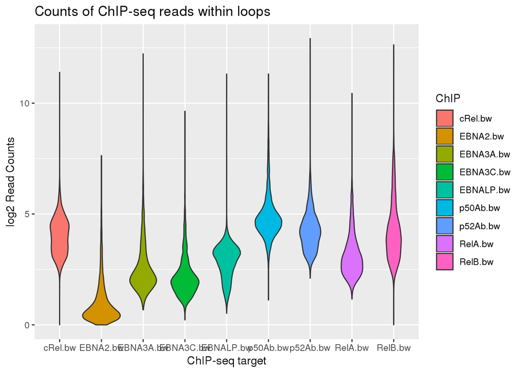

```r
ggplot(EBNA_qcLoops_df, aes(x = ChIP, y = Counts, fill = ChIP)) + geom_violin(trim = T) +
  labs(title = "Counts of ChIP-seq reads within loops", x = "ChIP-seq target", y = "log2 Read Counts")
```

```r
  #scale_x_discrete(limits = c('cRel',"EBNA2", "EBNA3A", "EBNA3C", "EBNALP",'p50_Ab','p52Ab','RelA','RelB'))
```

Lets split out the edgeR differential loops, this may make it better! First, annotate the peaks based on enhancer, promoter and CTCF Enhancer: ChromHMM Annotated Enhancers +/- 2kb Promoter: TSS +/- 2kb CTCF: CTCF peaks +/- 500bp ** Need to remove chr for annotateLoops to work **

```r
enhancerbed = "wgEncodeBroadHmmGm12878HMM_Enhancer.bed"
ctcfbed = "ENCFF833FTF.CTCF.bed"

enhancer = rmchr(padGRanges(bedToGRanges(enhancerbed), pad = 2000))
promoter <- rmchr(padGRanges(getHumanTSS(), pad = 2000)) # +/- 2kb
ctcf = rmchr(padGRanges(bedToGRanges(ctcfbed), pad = 500))
# Annotate the qcLoops object
seqlevels(qc_filt@anchors) <- gsub('chr','',seqlevels(qc_filt@anchors))
seqlevels(qcLoops_edgeR@anchors) <- gsub('chr','',seqlevels(qcLoops_edgeR@anchors))
km_anno <- annotateLoops(qcLoops_edgeR, enhancer = enhancer, promoter = promoter, ctcf = ctcf)
```

Distribution of loop types

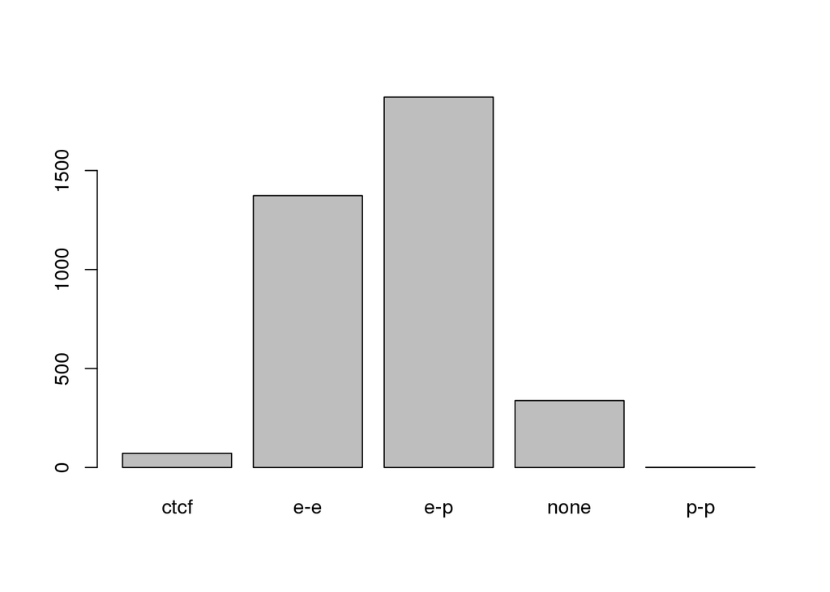

```r
barplot(table(km_anno@rowData$loop.type))
```

Repeat with 1.loops < 0.05 2.EP loops

```r
sig = 0.05
qcLoops_edgeR_sig = topLoops(km_anno, PValue = sig)
dim(qcLoops_edgeR_sig)
```

| anchors | interactions | samples | colData | rowData |
| --- | --- | --- | --- | --- |
| 327 | 169 | 4 | 2 | 9 |

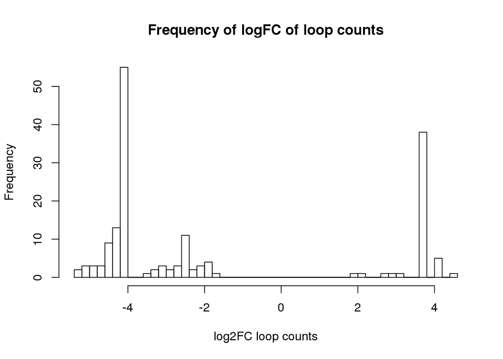

```r
hist(qcLoops_edgeR_sig@rowData$logFC, main = "Frequency of logFC of loop counts", xlab = "log2FC loop counts", breaks = 50)
```

ChIP-seq plots p < 0.05

```r
EBNA_qcLoops_sig = list()
for(i in 1:length(bw)){
  EBNA_qcLoops_sig[[names(bw)[i]]] = annotateAnchors.bigwig(qcLoops_edgeR_sig, bw[i], pad = 5000)
}
```

```r
EBNA_qcLoops_df_sig = as.data.frame(log2(annoGR2DF(EBNA_qcLoops_sig[[names(bw)[1]]]@anchors)[,5]))
colnames(EBNA_qcLoops_df_sig) = "Counts"
EBNA_qcLoops_df_sig$ChIP = unlist(strsplit(names(bw)[1], split = "_"))[1]
for(i in 1:(length(bw)-1)){
  temp =  as.data.frame(log2(annoGR2DF(EBNA_qcLoops_sig[[names(bw)[i+1]]]@anchors)[,5]))
  colnames(temp) = "Counts"
  temp$ChIP = unlist(strsplit(names(bw)[i+1], split = "_"))[1]
  EBNA_qcLoops_df_sig = rbind(EBNA_qcLoops_df_sig, temp)
}
```

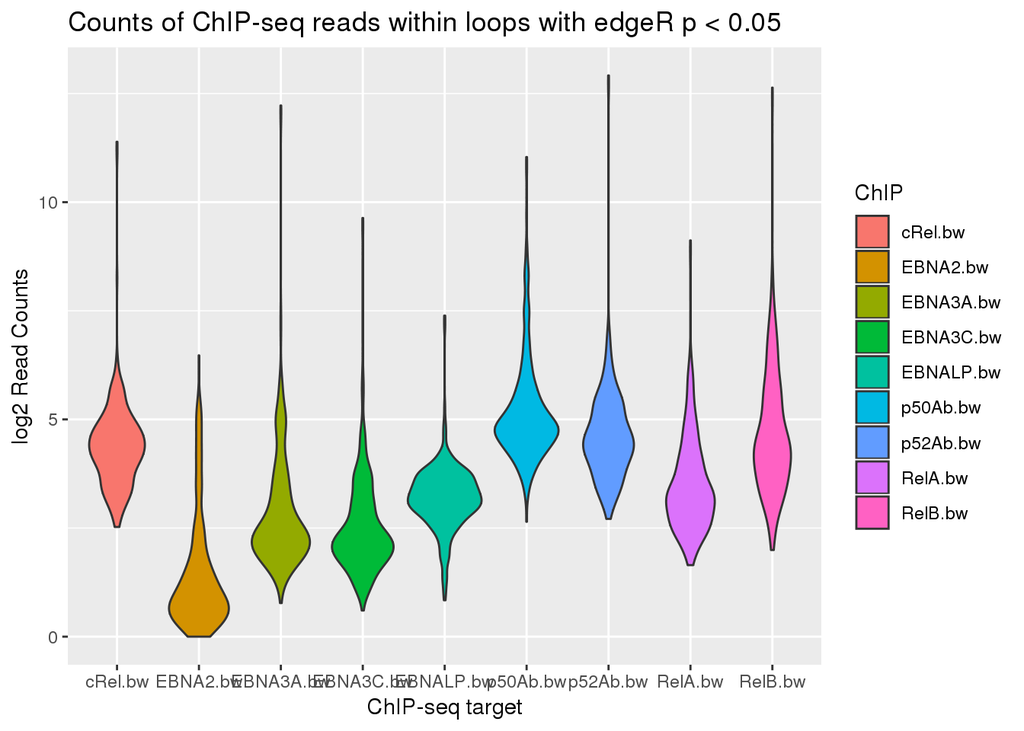

```r
ggplot(EBNA_qcLoops_df_sig, aes(x = ChIP, y = Counts, fill = ChIP)) + geom_violin(trim = T) +
  labs(title = "Counts of ChIP-seq reads within loops with edgeR p < 0.05", x = "ChIP-seq target", y = "log2 Read Counts")
```

```r
  #scale_x_discrete(limits = c('cRel',"EBNA2", "EBNA3A", "EBNA3C", "EBNALP",'p50_Ab','p52Ab','RelA','RelB'))
```

Confirming summary plot

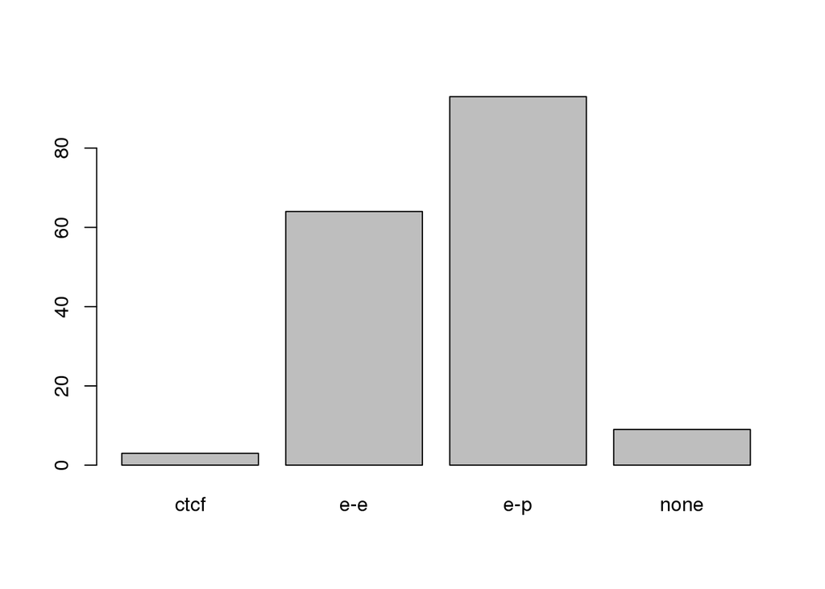

```r
barplot(table(topLoops(km_anno, PValue = sig)@rowData$loop.type))
```

Track only Enhancer-Promoter loops

First without p < 0.05 cutoff

```r
eploops = keepEPloops(km_anno, enhancer = enhancer, promoter = promoter)
dim(eploops)
```

| anchors | interactions | samples | colData | rowData |
| --- | --- | --- | --- | --- |
| 2781 | 1871 | 4 | 2 | 11 |

```r
EBNA_eploops = list()
for(i in 1:length(bw)){
  EBNA_eploops[[names(bw)[i]]] = annotateAnchors.bigwig(eploops, bw[i], pad = 5000)
}
```

```r
EBNA_eploops_df = as.data.frame(log2(annoGR2DF(EBNA_eploops[[names(bw)[1]]]@anchors)[,5]))
colnames(EBNA_eploops_df) = "Counts"
EBNA_eploops_df$ChIP = unlist(strsplit(names(bw)[1], split = "_"))[1]
for(i in 1:(length(bw)-1)){
  temp =  as.data.frame(log2(annoGR2DF(EBNA_eploops[[names(bw)[i+1]]]@anchors)[,5]))
  colnames(temp) = "Counts"
  temp$ChIP = unlist(strsplit(names(bw)[i+1], split = "_"))[1]
  EBNA_eploops_df = rbind(EBNA_eploops_df, temp)
}
```

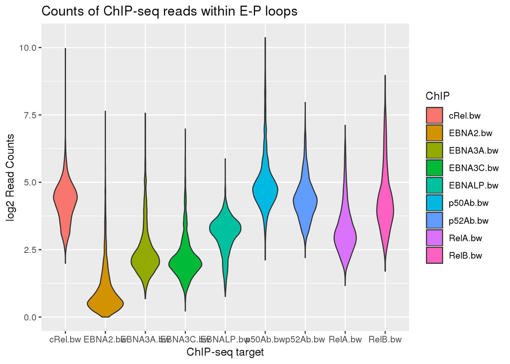

```r
ggplot(EBNA_eploops_df, aes(x = ChIP, y = Counts, fill = ChIP)) + geom_violin(trim = T) +
  labs(title = "Counts of ChIP-seq reads within E-P loops", x = "ChIP-seq target", y = "log2 Read Counts")
```

Summary plot confirming EP loops

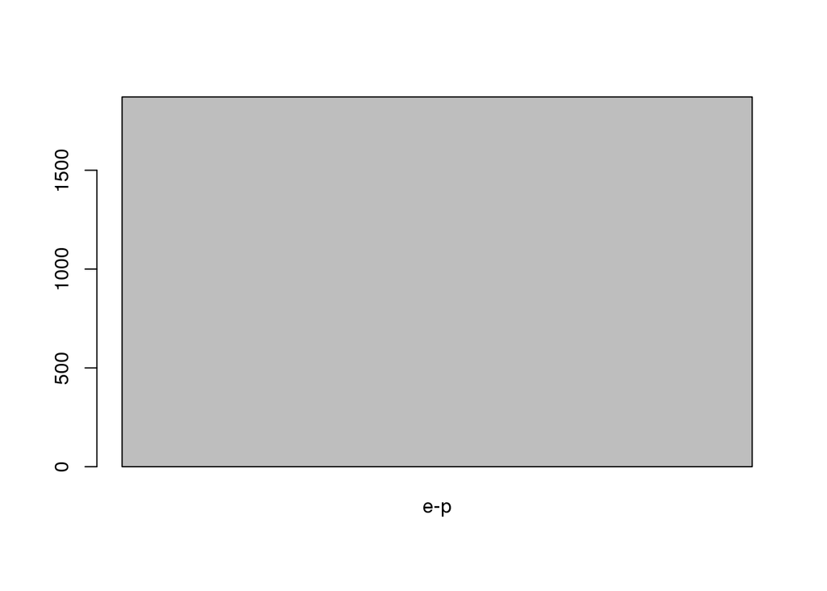

```r
barplot(table(eploops@rowData$loop.type))
```

Now with p < 0.05 cutoff and E-P

```r
sig = 0.05
eploops_sig = topLoops(eploops, PValue = sig)
dim(eploops)
```

| anchors | interactions | samples | colData | rowData |
| --- | --- | --- | --- | --- |
| 2781 | 1871 | 4 | 2 | 11 |

```r
dim(eploops_sig)
```

| anchors | interactions | samples | colData | rowData |
| --- | --- | --- | --- | --- |
| 183 | 93 | 4 | 2 | 11 |

```r
EBNA_eploops_sig = list()
for(i in 1:length(bw)){
  EBNA_eploops_sig[[names(bw)[i]]] = annotateAnchors.bigwig(eploops_sig, bw[i], pad = 5000)
}
```

```r
EBNA_eploops_df_sig = as.data.frame(log2(annoGR2DF(EBNA_eploops_sig[[names(bw)[1]]]@anchors)[,5]))
colnames(EBNA_eploops_df_sig) = "Counts"
EBNA_eploops_df_sig$ChIP = unlist(strsplit(names(bw)[1], split = "_"))[1]
for(i in 1:(length(bw)-1)){
  temp =  as.data.frame(log2(annoGR2DF(EBNA_eploops_sig[[names(bw)[i+1]]]@anchors)[,5]))
  colnames(temp) = "Counts"
  temp$ChIP = unlist(strsplit(names(bw)[i+1], split = "_"))[1]
  EBNA_eploops_df_sig = rbind(EBNA_eploops_df_sig, temp)
}
```

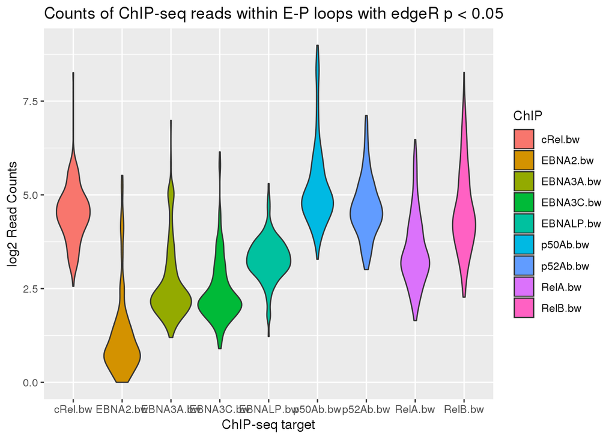

```r
ggplot(EBNA_eploops_df_sig, aes(x = ChIP, y = Counts, fill = ChIP)) + geom_violin(trim = T) +
  labs(title = "Counts of ChIP-seq reads within E-P loops with edgeR p < 0.05", x = "ChIP-seq target", y = "log2 Read Counts")
```

Summary plot confirming EP loops p < 0.05

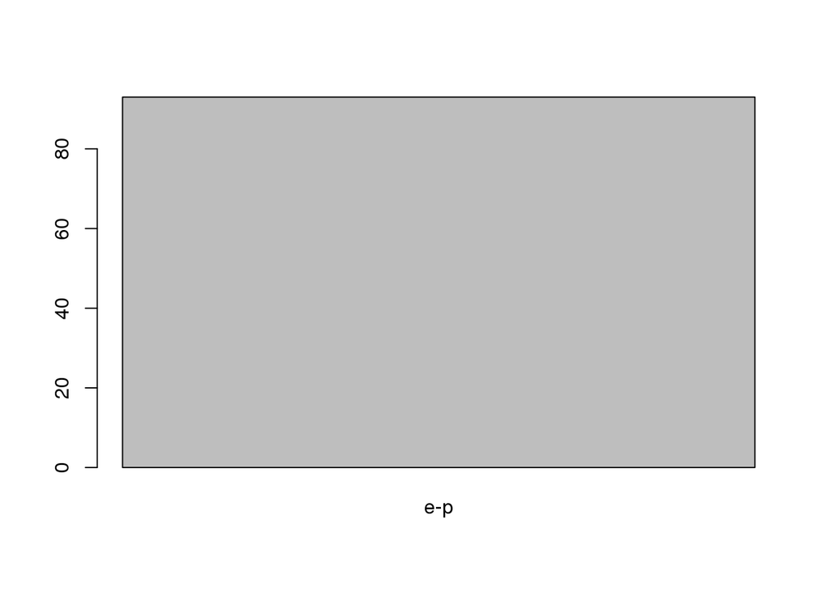

```r
barplot(table(eploops_sig@rowData$loop.type))
```

# Getting a data.frame back from a loops object using summary

```r
diffloop_df = summary(km_anno)
head(diffloop_df)
```

|  | chr_1 | start_1 | end_1 | chr_2 | start_2 | end_2 | GEN00140393.filt.intra | GEN00140394.filt.intra | GEN00140395.filt.intra | GEN00140396.filt.intra | loopWidth | mango.FDR | mango.P | logFC | logCPM | LR | PValue | FDR | loop.type | region |
| --- | --- | --- | --- | --- | --- | --- | --- | --- | --- | --- | --- | --- | --- | --- | --- | --- | --- | --- | --- | --- |
| 1 | 1 | 713191 | 716177 | 1 | 825037 | 827414 | 1 | 0 | 0 | 1 | 111541 | 8.526129e-04 | 3.678338e-04 | 0.1139718 | 7.671978 | 0.004673863 | 0.945494560 | 0.9493908 | none | chr1:688191-852414 |
| 2 | 1 | 998171 | 1001757 | 1 | 1139664 | 1143156 | 0 | 1 | 0 | 1 | 141446 | 1.425385e-05 | 1.388269e-06 | 0.1139718 | 7.671978 | 0.004673863 | 0.945494560 | 0.9493908 | e-p | chr1:973171-1168156 |
| 3 | 1 | 1071951 | 1076581 | 1 | 1234336 | 1236742 | 0 | 1 | 1 | 0 | 161273 | 7.957665e-05 | 1.794703e-05 | 0.1370326 | 7.680881 | 0.006309153 | 0.936690465 | 0.9493908 | none | chr1:1046951-1261742 |
| 4 | 1 | 2343905 | 2346095 | 1 | 2515688 | 2518009 | 0 | 1 | 0 | 1 | 171848 | 1.275408e-06 | 1.039210e-07 | 0.1139718 | 7.671978 | 0.004673863 | 0.945494560 | 0.9493908 | e-p | chr1:2318905-2543009 |
| 5 | 1 | 2476096 | 2481428 | 1 | 2485419 | 2491852 | 3 | 7 | 0 | 0 | 9873 | 5.365284e-03 | 2.743859e-03 | -5.2839468 | 8.508211 | 10.278598267 | 0.001345822 | 0.3922627 | e-p | chr1:2451096-2516852 |
| 6 | 1 | 2508737 | 2510778 | 1 | 2515688 | 2518009 | 2 | 6 | 1 | 4 | 7091 | 1.909407e-04 | 6.184145e-05 | -0.5248210 | 8.734096 | 0.301015351 | 0.583246586 | 0.9493908 | e-p | chr1:2483737-2543009 |

Now try to look at only pvalue < 0.05 and the interactions from ChIP-seq (this should be the same plot as above using topLoops!! Sanity Check!)

```r
sig = 0.05
diffloop_sig = diffloop_df[diffloop_df$PValue < 0.05,]
dim(diffloop_sig)
```

```
[1] 169  20
```

```r
head(diffloop_sig)
```

|  | chr_1 | start_1 | end_1 | chr_2 | start_2 | end_2 | GEN00140393.filt.intra | GEN00140394.filt.intra | GEN00140395.filt.intra | GEN00140396.filt.intra | loopWidth | mango.FDR | mango.P | logFC | logCPM | LR | PValue | FDR | loop.type | region |
| --- | --- | --- | --- | --- | --- | --- | --- | --- | --- | --- | --- | --- | --- | --- | --- | --- | --- | --- | --- | --- |
| 5 | 1 | 2476096 | 2481428 | 1 | 2485419 | 2491852 | 3 | 7 | 0 | 0 | 9873 | 5.365284e-03 | 2.743859e-03 | -5.283947 | 8.508211 | 10.278598 | 0.001345822 | 0.3922627 | e-p | chr1:2451096-2516852 |
| 24 | 1 | 12078618 | 12080627 | 1 | 12106893 | 12108953 | 5 | 4 | 0 | 1 | 28300 | 2.223230e-04 | 7.521395e-05 | -2.760228 | 8.508211 | 4.998903 | 0.025363382 | 0.3922627 | e-p | chr1:12053618-12133953 |
| 39 | 1 | 24125033 | 24127661 | 1 | 24235475 | 24236920 | 0 | 0 | 1 | 2 | 109850 | 1.704897e-04 | 5.349992e-05 | 3.767468 | 7.816433 | 4.130036 | 0.042128455 | 0.3922627 | e-p | chr1:24100033-24261920 |
| 127 | 1 | 63832680 | 63834409 | 1 | 63988284 | 63990146 | 1 | 3 | 0 | 0 | 155670 | 1.054090e-09 | 3.628664e-11 | -4.016520 | 7.931646 | 4.644454 | 0.031154048 | 0.3922627 | e-p | chr1:63807680-64015146 |
| 170 | 1 | 111175885 | 111178679 | 1 | 111308153 | 111310119 | 0 | 0 | 2 | 2 | 131854 | 6.882579e-11 | 1.657341e-12 | 4.166895 | 7.948593 | 5.401418 | 0.020120399 | 0.3922627 | e-p | chr1:111150885-111335119 |
| 175 | 1 | 111755823 | 111758150 | 1 | 111764397 | 111765968 | 6 | 12 | 1 | 3 | 8196 | 6.792994e-05 | 1.368391e-05 | -1.967532 | 9.239336 | 4.771827 | 0.028929111 | 0.3922627 | e-e | chr1:111730823-111790968 |

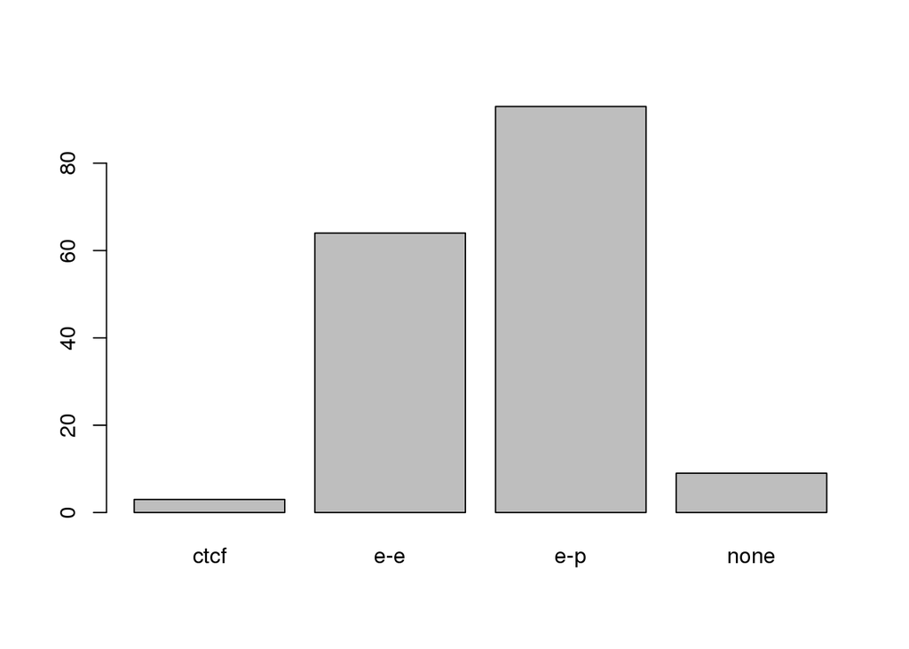

```r
barplot(table(diffloop_sig$loop.type))
```

# Write out dataframe

```r
write.csv(diffloop_df, file = "differential_loops_EBNA3C_all.csv")
```

# Plotting

Plot the top n peaks

```r
# plotTopLoops(km_anno, n = 100, PValue = 0.05, organism = "h", colorLoops = T)
```

Plot the top n peaks for ep interactions

```r
# plotTopLoops(eploops, n = 100, PValue = 0.05, organism = "h", colorLoops = T)
```

Plot CDKN2A and MYC

```r
# CDKN2A: chr9:21,393,258-22,568,984
# MYC: chr8:128,183,348-128,792,652
reg_CDKN2A = GRanges(c('9'), IRanges(c(21393000), c(22569000)))
reg_MYC = GRanges(c('8'), IRanges(c(128183000), c(128793000)))
# loops_CDKN2A = subsetRegion(qcLoops_edgeR_sig, reg_CDKN2A)
# loops_MYC = subsetRegion(qcLoops_edgeR_sig, reg_MYC)
```

Loop plot red loops bridge enhancers and promoters, purple loops bridge two enhancers, orange loops bridge two promoters, blue loops bridge CTCF regions and black are not annotated

```r
manyLoopPlots(qcLoops_edgeR_sig, reg_CDKN2A, colorLoops = T)
manyLoopPlots(qcLoops_edgeR_sig, reg_MYC, colorLoops = T, maxCounts = 10)
```

[output not shown]

IRFs and such

```r
# IRF2, IRF4, BATF, SPI1
# chr4:184,520,535-186,112,064
# chr6:196,769-552,939
# chr14:75,777,614-76,224,503
# chr11:47,107,256-47,669,279

reg_IRFs = GRanges(c('4','6','14','11'), IRanges(c(184520535, 196769, 75777614, 47107256), c(186112064, 552939, 76224503, 47669279)))
manyLoopPlots(qcLoops_edgeR_sig, reg_IRFs, colorLoops = T)
```

[output not shown]

Plot up and downregulated loops with subsetLoops and redo analysis on subset loops LogFC positive means upregulated in ON LogFC negative means upregaulted in OFF

```r
# subsetLoops(dlo, idxa)
up_ON = subsetLoops(qcLoops_edgeR_sig, qcLoops_edgeR_sig@rowData$logFC > 0)
down_ON = subsetLoops(qcLoops_edgeR_sig, qcLoops_edgeR_sig@rowData$logFC < 0)
```

```r
EBNA_up_ON = list()
for(i in 1:length(bw)){
  EBNA_up_ON[[names(bw)[i]]] = annotateAnchors.bigwig(up_ON, bw[i], pad = 5000)
}
```

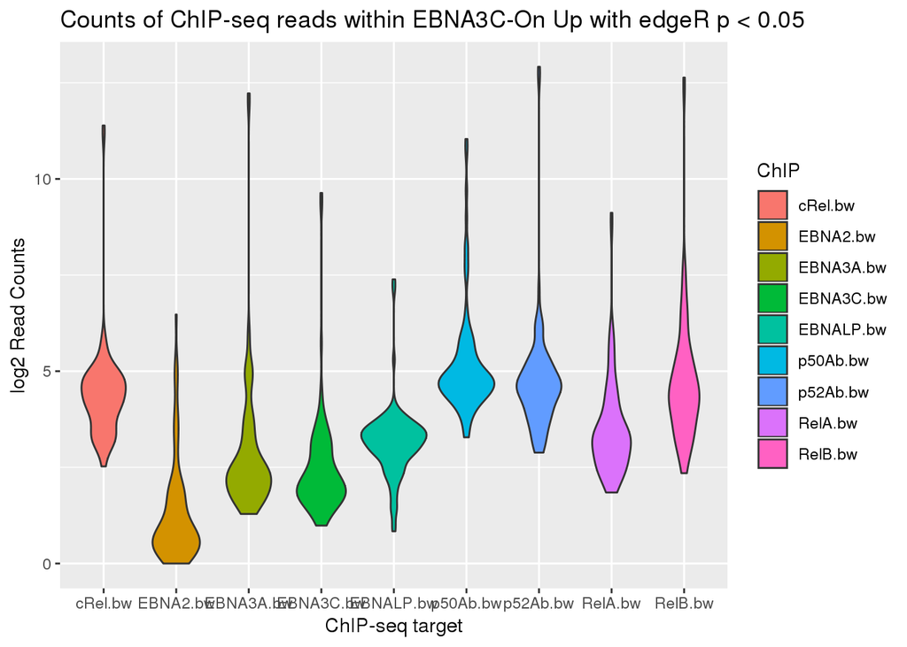

```r
EBNA_up_ON_df = as.data.frame(log2(annoGR2DF(EBNA_up_ON[[names(bw)[1]]]@anchors)[,5]))
colnames(EBNA_up_ON_df) = "Counts"
EBNA_up_ON_df$ChIP = unlist(strsplit(names(bw)[1], split = "_"))[1]
for(i in 1:(length(bw)-1)){
  temp =  as.data.frame(log2(annoGR2DF(EBNA_up_ON[[names(bw)[i+1]]]@anchors)[,5]))
  colnames(temp) = "Counts"
  temp$ChIP = unlist(strsplit(names(bw)[i+1], split = "_"))[1]
  EBNA_up_ON_df = rbind(EBNA_up_ON_df, temp)
}
ggplot(EBNA_up_ON_df, aes(x = ChIP, y = Counts, fill = ChIP)) + geom_violin(trim = T) +
  labs(title = "Counts of ChIP-seq reads within EBNA3C-On Up with edgeR p < 0.05", x = "ChIP-seq target", y = "log2 Read Counts")
```

```r
EBNA_down_ON = list()
for(i in 1:length(bw)){
  EBNA_down_ON[[names(bw)[i]]] = annotateAnchors.bigwig(down_ON, bw[i], pad = 5000)
}
```

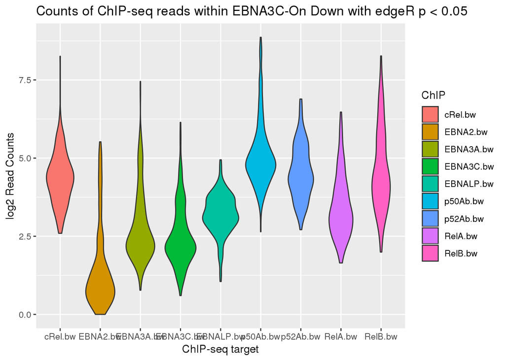

```r
EBNA_down_ON_df = as.data.frame(log2(annoGR2DF(EBNA_down_ON[[names(bw)[1]]]@anchors)[,5]))
colnames(EBNA_down_ON_df) = "Counts"
EBNA_down_ON_df$ChIP = unlist(strsplit(names(bw)[1], split = "_"))[1]
for(i in 1:(length(bw)-1)){
  temp =  as.data.frame(log2(annoGR2DF(EBNA_down_ON[[names(bw)[i+1]]]@anchors)[,5]))
  colnames(temp) = "Counts"
  temp$ChIP = unlist(strsplit(names(bw)[i+1], split = "_"))[1]
  EBNA_down_ON_df = rbind(EBNA_down_ON_df, temp)
}
ggplot(EBNA_down_ON_df, aes(x = ChIP, y = Counts, fill = ChIP)) + geom_violin(trim = T) +
  labs(title = "Counts of ChIP-seq reads within EBNA3C-On Down with edgeR p < 0.05", x = "ChIP-seq target", y = "log2 Read Counts")
```

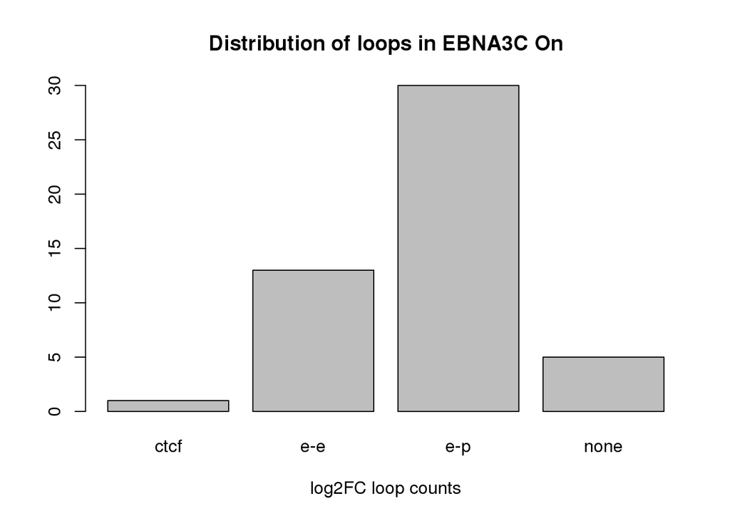

```r
barplot(table(up_ON@rowData$loop.type), main = "Distribution of loops in EBNA3C On", xlab = "log2FC loop counts")
```

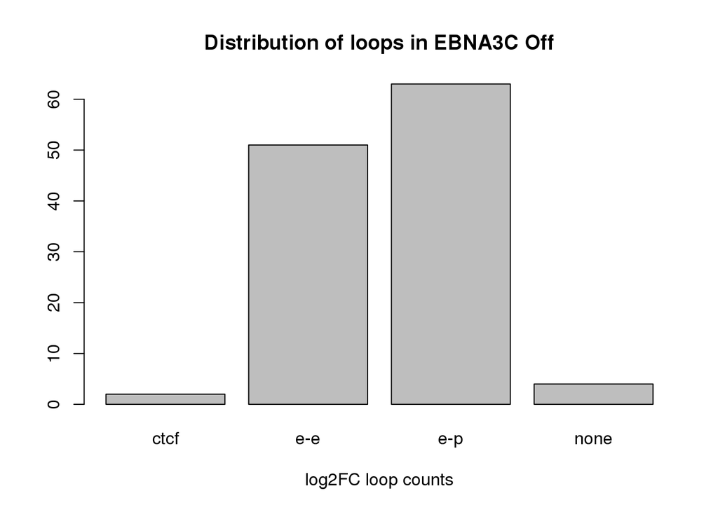

```r
barplot(table(down_ON@rowData$loop.type), main = "Distribution of loops in EBNA3C Off", xlab = "log2FC loop counts")
```

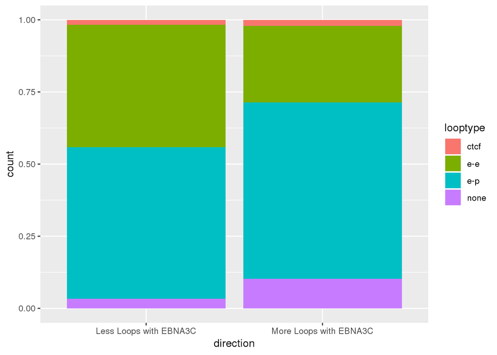

```r
up_freq = as.data.frame(up_ON@rowData$loop.type)
colnames(up_freq) = "looptype"
up_freq$direction = "More Loops with EBNA3C"
down_freq = as.data.frame(down_ON@rowData$loop.type)
colnames(down_freq) = "looptype"
down_freq$direction = "Less Loops with EBNA3C"
updown_freq = rbind(up_freq, down_freq)
ggplot(updown_freq, aes(x = direction, fill = looptype)) + geom_bar(position = "fill")
```